# Bitwise Operators and Bitboards

A brief introduction

Maxim Rebguns

November 2023

# About Me

## Maxim Rebguns

- Computer scientist
  - Favorite languages: C and Python
  - Worked with different algorithms, embedded systems, web development, game development
- Avid Linux user
- Theater kid

# Binary data

## Binary as a number system

- Just like with decimal numbers, but instead of 0–9, we only have 0 and 1.
- We use place values, just like with base-10 (decimal) numbers.

## Representing data in binary

- Integers: place value, two’s complement
- Real numbers: floating-point, fixed-point, logarithmic
- Characters: ASCII, UTF-8
- Pointers? Arrays? Structures? Classes?

## Getting rid of the abstraction

[figure not shown]

Average programmer

- It’s all just bits under the hood

# Bitwise operators

## Purpose

Why would we need to manipulate individual bits?

- Representing true or false data
- Embedded systems
- Cryptography
- Compression
- Graphics
- Speed
- Certain data structures

## Bitwise AND (binary)

| A | B | ? |
| --- | --- | --- |
| 0 | 0 | 0 |
| 0 | 1 | 0 |
| 1 | 0 | 0 |
| 1 | 1 | 1 |

Performs an AND operation on each bit:

```
  011010100
& 101001101
  ---------
  001000100
```

We are intersecting our two inputs

## Bitwise OR (binary)

| A | B | ? |
| --- | --- | --- |
| 0 | 0 | 0 |
| 0 | 1 | 1 |
| 1 | 0 | 1 |
| 1 | 1 | 1 |

Performs an OR operation on each bit:

```
  011010100
| 101001101
  ---------
  111011101
```

We are unioning our two inputs

## Bitwise XOR (binary)

| A | B | ? |
| --- | --- | --- |
| 0 | 0 | 0 |
| 0 | 1 | 1 |
| 1 | 0 | 1 |
| 1 | 1 | 0 |

Performs an XOR operation on each bit:

```
  011010100
^ 101001101
  ---------
  110011001
```

We are taking the symmetric difference of our two inputs

## Bitwise NOT (unary)

| A | ? |
| --- | --- |
| 0 | 1 |
| 1 | 0 |

Performs a NOT operation on each bit:

```
~ 011010100
  ---------
  100101011
```

We are negating our one input

## Left/Right Shift (binary)

Allows you to shift all bits of a number to the left or right by another number.

```
0010110 >> 10 becomes 0000101
0010110 << 10 becomes 1011000
```

- Note that 10 in binary means 2 in decimal.
- Typically we represent the shift amount in decimal for easier understanding.

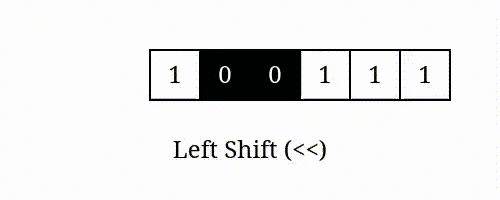

Left shift. A right shift is the same but in the other direction

# Bitboards

## Intro to bitboards

Let’s look at an application of bitwise operators that is often used for representing grids in games: **bitboards**

- A way to represent a grid of binary numbers in a single integer.
- Highly compact.
- Allows for boolean operations using bitwise operators.
- Very useful for gridded board games.

## The intuitive method

**Goal**: Create a grid representing the tic-tac-toe board.

| o | x | x |
| --- | --- | --- |
|  | x |  |
| o | o |  |

```c
typedef enum { MOVE_EMPTY, MOVE_X, MOVE_O } move;
move board[][] = {
    {MOVE_O, MOVE_X, MOVE_X},
    {MOVE_EMPTY, MOVE_X, MOVE_EMPTY},
    {MOVE_O, MOVE_O, MOVE_EMPTY}
};
```

## Enter bitboards

What if we represented the board as two binary numbers, one for each side?

[output not shown]

```c
typedef uint16_t board;

//                    123456789
board x_positions = 0b011100000;
board o_positions = 0b100000110;
```

## Things you can do with bitboards

- Get an intuitive understanding: https://tearth.dev/bitboard-viewer/
- Get a bitboard representing all taken positions:

  ```c
  board taken_positions = x_positions | o_positions;
  ```

- Check if a player’s move is valid:

  ```c
  board valid_positions = ~taken_positions;
  bool is_valid = (move & valid_positions) != 0;
  ```

## More bitboard tricks

- There are 8 ways to win in tic-tac-toe. You can represent these 8 board positions as bitboards, and then AND them with the player’s positions to see if they won:

  ```c
  bool has_won = ((board & l_vert_win) == l_vert_win)
                  || (board & m_vert_win) == m_vert_win)
                  || ...);
  ```

- Bitwise operators allow you to manipulate bits efficiently, which is what makes this a great methods for complex games like chess.

## Conclusion

- There are a truckload of ways to represent data with binary.
- Bitboards are one of them.
- Bitwise operators allow for the manipulation of individual bits of data.
- This is extremely fast and broadly applicable.

# Thanks!

## Credits

- [Binary Representation [pdf]](https://courses.cs.washington.edu/courses/cse410/22wi/lectures/03-binaryRepresentation.pdf)
- [Wikipedia: Floating-pint arithmetic](https://en.wikipedia.org/wiki/Floating-point_arithmetic)
- [StackOverflow: Real world use cases of bitwise operators](https://stackoverflow.com/questions/2096916/)
- [Wikipedia: Bitwise operation](https://en.wikipedia.org/wiki/Bitwise_operation%3E)
- [Wikipedia: Bitwise operators in C](https://en.wikipedia.org/wiki/Bitwise_operations_in_C)
- [Chess Programming Wiki: Bitboards](https://www.chessprogramming.org/Bitboards)

## About

This work [accessible here](https://mrmaxguns.github.io/documents/) by [Maxim Rebguns](https://mrmaxguns.github.io) is licensed under [CC BY 4.0](http://creativecommons.org/licenses/by/4.0/)